# afg_villages_cold_perc

Author

JMR

## Code

### Set Up

In the setup, we create the paths to the various data sources and load the necessary functions for extraction. Note `..` means one step back to the folder directory, i.e. one folder back.

```r
path_to_data <- file.path("..",
                          "..", "data")

path_to_tmp_min <- file.path(path_to_data, "weather", "ERA5_Land", "AFG", "daily",
                             "2m_temperature")

path_to_village <- file.path(path_to_data, "survey", "AFG",
                             "Village coordinates_CoF(Village level coordinates).csv")

path_to_adm_div <- file.path(path_to_data, "adm_div", "UN_borders", "UN-AFG-ADM2.gpkg")
```

```r
library(climatic4economist)
```

### Load the data

Let’s start by loading the data into R. We load the weather observation with the function `terra::rast()`. As the raw data is made of two different files, we first load each one with the `lapply()` function and than we aggregate them with the `terra::rast()` function. Note that we changed the order of the list item to have them ordered by date. This has no computational implication for this tutorial but it is nicer.

> We set the names of the layer as the date of observation. This is very important for later.

```r
tmp_min_k <- list.files(path_to_tmp_min, full.names = TRUE) |>
  lapply(terra::rast)
tmp_min_k
```

```
[[1]]
class       : SpatRaster
dimensions  : 101, 151, 811  (nrow, ncol, nlyr)
resolution  : 0.1, 0.1  (x, y)
extent      : 59.95, 75.05, 28.95, 39.05  (xmin, xmax, ymin, ymax)
coord. ref. : lon/lat WGS 84
source      : day_23_25_2m_tmp_min.nc
names       : day_2~min_1, day_2~min_2, day_2~min_3, day_2~min_4, day_2~min_5, day_2~min_6, ...
time (days) : 2023-01-01 to 2025-03-21

[[2]]
class       : SpatRaster
dimensions  : 101, 151, 26663  (nrow, ncol, nlyr)
resolution  : 0.1, 0.1  (x, y)
extent      : 59.95, 75.05, 28.95, 39.05  (xmin, xmax, ymin, ymax)
coord. ref. : lon/lat WGS 84
source      : day_50_22_2m_tmp_min.nc
varname     : day_50_22_2m_temperature
names       : day_5~ure_1, day_5~ure_2, day_5~ure_3, day_5~ure_4, day_5~ure_5, day_5~ure_6, ...
time (days) : 1950-01-01 to 2022-12-31
```

```r
tmp_min_k <- terra::rast(list(tmp_min_k[[2]], tmp_min_k[[1]]))

names(tmp_min_k) <- terra::time(tmp_min_k)
tmp_min_k
```

```
class       : SpatRaster
dimensions  : 101, 151, 27474  (nrow, ncol, nlyr)
resolution  : 0.1, 0.1  (x, y)
extent      : 59.95, 75.05, 28.95, 39.05  (xmin, xmax, ymin, ymax)
coord. ref. : lon/lat WGS 84
sources     : day_50_22_2m_tmp_min.nc  (26663 layers)
              day_23_25_2m_tmp_min.nc  (811 layers)
varnames    : day_50_22_2m_temperature
              day_23_25_2m_tmp_min
names       : 1950-01-01, 1950-01-02, 1950-01-03, 1950-01-04, 1950-01-05, 1950-01-06, ...
time (days) : 1950-01-01 to 2025-03-21
```

Now we load the villages. We rename the variable for easier use.

> It is very important to check if the village and the raster data share the same coordinate reference system!

Usually, the WGS 84 CRS is the default coordinate references system for coordinates. In this case it matches the weather coordinate references system.

```r
village <- data.table::fread(path_to_village) |>
    dplyr::rename(lon = "Longitude (X)",
                  lat = "Latitude (Y)")
village
```

```
       Province   District           Village Treatment/Control assignment
  1: Badakhshan      Khash            Buqluk                    Treatment
  2: Badakhshan      Khash           Darkhan                    Treatment
  3: Badakhshan      Khash           Deh Naw                    Treatment
  4: Badakhshan      Khash           Dehpara                    Treatment
  5: Badakhshan      Khash        Kaj Gardan                    Treatment
 ---
131:    Badghis Qala-e-Naw       Deh Sorkhak                    Treatment
132:    Badghis Qala-e-Naw          Najak Ha                    Treatment
133:    Badghis Qala-e-Naw       Qaria Kalan                    Treatment
134:    Badghis Qala-e-Naw          Qarqaito                    Treatment
135:    Badghis Qala-e-Naw Rais Sharaf Paein                    Treatment
          lat      lon
  1: 36.90510 70.75978
  2: 37.02285 70.75433
  3: 36.92896 70.76638
  4: 36.90668 70.75284
  5: 36.89553 70.76962
 ---
131: 34.97695 63.12751
132: 34.79436 63.25978
133: 34.97737 63.12534
134: 34.97661 63.12920
135: 35.01004 63.12812
```

We load the administrative divisions to check where the villages are.

```r
adm_div <- terra::vect(path_to_adm_div)
adm_div
```

```
 class       : SpatVector
 geometry    : polygons
 dimensions  : 399, 11  (geometries, attributes)
 extent      : 60.5176, 74.88986, 29.3772, 38.48959  (xmin, xmax, ymin, ymax)
 source      : UN-AFG-ADM2.gpkg
 coord. ref. : lon/lat WGS 84 (EPSG:4326)
 names       : ISO3CD      ROMNAM     ADM1NM      ADM2NM      MAPLAB ADM1CD
 type        :  <chr>       <chr>      <chr>       <chr>       <chr>  <chr>
 values      :    AFG Afghanistan Badakhshan Arghanjkhwa Afghanistan AFG001
                  AFG Afghanistan Badakhshan        Argo Afghanistan AFG001
                  AFG Afghanistan Badakhshan     Baharak Afghanistan AFG001
    ADM2CD     DATSOR ADMSOR Shape_STAr Shape_STLe
     <chr>      <chr>  <int>      <num>      <num>
 AFG001020 28/03/2017      2     0.2369       2.94
 AFG001014 28/03/2017      2      0.107      1.897
 AFG001019 28/03/2017      2    0.03324     0.9186
```

### Georeference the survey

As we’ve mentioned, the weather data is georeferenced, so we need to ensure the same for the survey data.

we must ensure that we can later associate the correct weather data with the right household, we do this by creating an merging variable called `ID`.

This is handled by the `prepare_coord()` function, which requires the coordinates’ variable names as input.

Once we have the unique coordinates, we are ready to transform them into spatial points using the `georef_coord()` function. When performing this transformation, it’s crucial to set the correct CRS, which must match that of the weather data. The CRS is provided as an argument of the function, using the previously saved CRS from the weather data. Also the `georef_coord()` function requires the coordinates’ variable names as input.

```r
village_coord <- prepare_coord(village,
                               lon_var = lon,
                               lat_var = lat)

village_geo <- georef_coord(village_coord,
                 geom = c("lon", "lat"),
                 crs = "EPSG:4326")
village_geo
```

```
 class       : SpatVector
 geometry    : points
 dimensions  : 135, 1  (geometries, attributes)
 extent      : 63.04077, 73.07026, 34.68098, 37.92406  (xmin, xmax, ymin, ymax)
 coord. ref. : lon/lat WGS 84 (EPSG:4326)
 names       :    ID
 type        : <int>
 values      :     1
                   2
                   3
```

### Plot

A good practice when working with spatial data is to plot it. This is the best way to verify that everything is working as expected.

First, we plot the administrative division and the villages to ensure they are correctly located and we examine their spatial distribution.

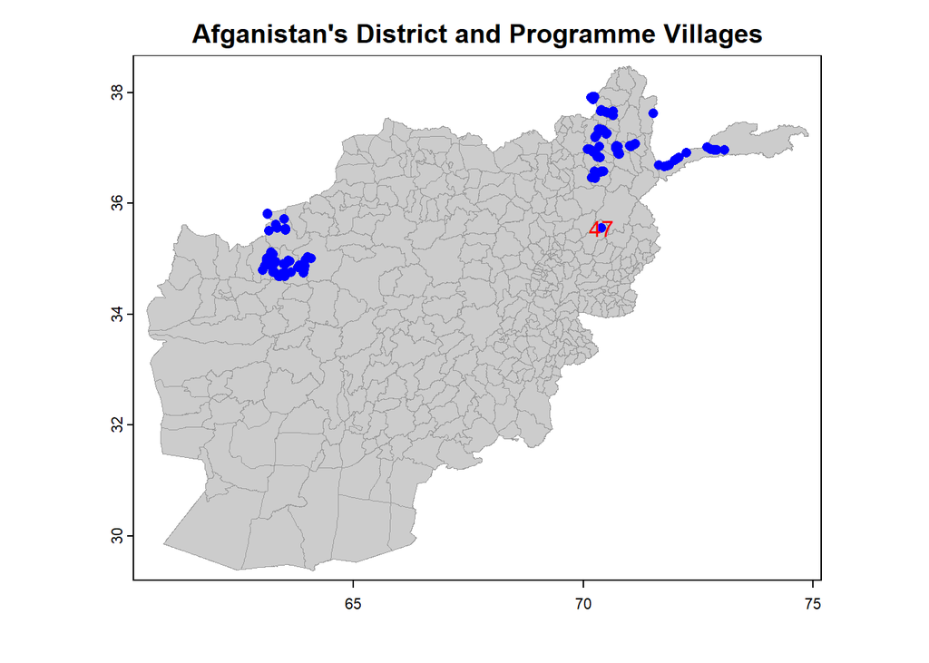

```r
terra::plot(adm_div,
            col = "grey80",
            border="grey60",
            lwd = 0.1,
            main = "Afganistan's District and Programme Villages")
terra::points(village_geo, col = "blue", cex = 1)

village_geo |>
    tidyterra::filter(ID == 47) |>
    terra::text("ID", col = "red")
```

We can see that the village `ID == 47` is isolated fro the other villages, which tend to cluster in two distinct areas. I would suggest to double check the accuracy of this village.

```r
village_coord |>
    dplyr::filter(ID == 47) |>
    knitr::kable()
```

| ID | Province | District | Village | Treatment/Control assignment | lat | lon |
| --- | --- | --- | --- | --- | --- | --- |
| 47 | Badakhshan | Tagab | Rubat Kato Bala | Control | 35.55581 | 70.39127 |

Next, we plot a layer of the minimum temperature data to see how it overlaps with the spatial coordinates.

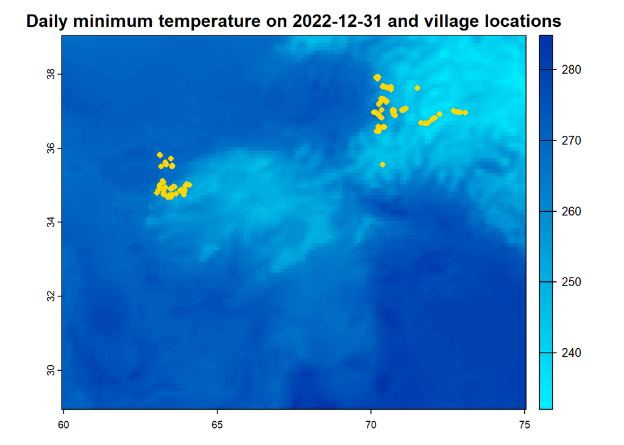

```r
terra::plot(tmp_min_k, "2022-12-31", col = terra::map.pal("water"),
            main = "Daily minimum temperature on 2022-12-31 and village locations")
terra::points(village_geo, col = "gold", cex = 0.8)
```

Once again, the villages coordinates align with the temperature data, which is great!

### Extract

Next, we extract the weather data based on the village coordinates using the `extract_by_coord()` function. This function requires the raster with the weather data and the georeferenced coordinates as inputs.

Looking at the result, we see first the `ID` column, that identifies the village coordinates. The second and third column are the coordinates of the cells. The other columns contain the weather observations over time specific to each coordinate.

```r
tmin_village_k <- extract_by_coord(raster = tmp_min_k,
                                   coord = village_geo)
tmin_village_k
```

```
# A tibble: 135 × 27,477
      ID x_cell y_cell `1950-01-01` `1950-01-02` `1950-01-03` `1950-01-04`
   <int>  <dbl>  <dbl>        <dbl>        <dbl>        <dbl>        <dbl>
 1     1   63.4   34.7         253.         257.         257.         258.
 2     2   63.4   34.7         253.         257.         257.         258.
 3     3   63.5   34.7         253.         260.         258.         259.
 4     4   63.5   34.7         253.         260.         258.         259.
 5     5   63.4   34.7         253.         257.         257.         258.
 6     6   63.5   34.7         253.         260.         258.         259.
 7     7   63.9   34.7         253.         256.         256.         257.
 8     8   63.3   34.8         255.         262.         261.         260.
 9     9   63.3   34.8         255.         262.         261.         260.
10    10   63.3   34.8         255.         262.         261.         260.
# ℹ 125 more rows
# ℹ 27,470 more variables: `1950-01-05` <dbl>, `1950-01-06` <dbl>,
#   `1950-01-07` <dbl>, `1950-01-08` <dbl>, `1950-01-09` <dbl>,
#   `1950-01-10` <dbl>, `1950-01-11` <dbl>, `1950-01-12` <dbl>,
#   `1950-01-13` <dbl>, `1950-01-14` <dbl>, `1950-01-15` <dbl>,
#   `1950-01-16` <dbl>, `1950-01-17` <dbl>, `1950-01-18` <dbl>,
#   `1950-01-19` <dbl>, `1950-01-20` <dbl>, `1950-01-21` <dbl>, …
```

Again we have a row for each unique village. However, if we want to know how many different cells there are we can look unique cell coordinates.

```r
unique_cell <- tmin_village_k |>
  dplyr::distinct(x_cell, y_cell)
nrow(unique_cell)
```

```
[1] 61
```

We see that now the number of rows is 61, this is the actual different weather observation that we can merge with the villages. In other words, many villages share the same weather observation as they fall within the same pixel.

### Prepare data

The original unit of measure of the temperature in Kelvin, we change it into Celsius.

```r
tmin_village_c <- tmin_village_k |>
  dplyr::mutate(dplyr::across(.cols = dplyr::matches("[0-9]{4}"),
                              .fns = ~ .x - 273.15))
```

Before calculating the percentile we select just the observations after 1980 with the function `select_by_dates()`. Indeed, 30 years is usually considered enough observation to evaluate climatic parameters, and weather observation before 1980 are considered less reliable.

```r
tmin_village_c_80 <- select_by_dates(tmin_village_c, from = "1980-01-01")
```

### Calculate percentiles

> If we believe the thresholds shouldn’t be the same across all the location but instead be adaptive to the local long run climatic condition we should use the relative thresholds. In this case the thresholds varies for each location, adapting to the local climatic features and making the spatial comparison among heterogeneous places more meaningful. The relative approach measures the extreme weather events in term of their rarity, which is measured by the percentile of their local and seasonal distribution.

We now calculate the percentiles with the function `calc_pct_day()`. The functions requires the weather observations with the additional variable `ID` and the desired percentiles to be computed.

We are interested in cold percentiles, therefore we calculate the extreme percentiles of the left tail.

Eventually, we could also have provided two additional arguments to the function. These are `l_thresh` and `u_thresh`, which removes the observations which are below the `l_thresh` or above `u_thresh`. For example, since we are looking for cold percentile we could have add `u_thresh = 0` to filter out all temperatures above zero degree Celsius and leave just the cold observations. This can be interpreted as an upper bound of the cold percentiles which will never be above the `u_thresh`.

```r
tmin_min_pct <- calc_pct_day(tmin_village_c_80, p = c(0.01, 0.05, 0.1), yearly = TRUE)
tmin_min_pct
```

```
       ID month      day_1p     day_5p    day_10p     yr_1p     yr_5p    yr_10p
   1:   1    01 -26.5504288 -22.476588 -20.609671 -22.11882 -16.02409 -11.82053
   2:   1    02 -25.6667212 -21.528326 -18.361588 -22.11882 -16.02409 -11.82053
   3:   1    03 -20.0699242 -14.819304 -12.012686 -22.11882 -16.02409 -11.82053
   4:   1    04  -8.6648682  -3.904947  -2.446277 -22.11882 -16.02409 -11.82053
   5:   1    05  -0.9912347   1.626505   3.320831 -22.11882 -16.02409 -11.82053
  ---
1616: 135    08   9.2610254  11.183493  11.953339 -17.90213 -13.53596 -10.34284
1617: 135    09   3.8027396   6.340689   7.493677 -17.90213 -13.53596 -10.34284
1618: 135    10 -12.3095746  -2.839771  -1.582959 -17.90213 -13.53596 -10.34284
1619: 135    11 -18.3918468 -14.837869 -11.386707 -17.90213 -13.53596 -10.34284
1620: 135    12 -20.2207773 -17.491631 -15.787708 -17.90213 -13.53596 -10.34284
```

The first two columns of the result identify the unique location and the month. The month is important as we compute the statistic for each month to account for climatic seasonality.

> Note that even if we compute the statitics for each month the unit of measure refer to the daily minimum temperature.

### Merge with survey

Now, we combine the extracted weather data with the village data using `merge_with_survey()`, which under the hood uses the variable `ID` as the key matching variable.

```r
tmin_pct_village <- merge_with_survey(village_coord, tmin_min_pct)
tmin_pct_village
```

```
# A tibble: 1,620 × 14
      ID Province District Village      Treatment/Control as…¹   lat   lon month
   <int> <chr>    <chr>    <chr>        <chr>                  <dbl> <dbl> <chr>
 1     1 Badghis  Qadis    Jawaleq Olia Control                 34.7  63.4 01
 2     1 Badghis  Qadis    Jawaleq Olia Control                 34.7  63.4 02
 3     1 Badghis  Qadis    Jawaleq Olia Control                 34.7  63.4 03
 4     1 Badghis  Qadis    Jawaleq Olia Control                 34.7  63.4 04
 5     1 Badghis  Qadis    Jawaleq Olia Control                 34.7  63.4 05
 6     1 Badghis  Qadis    Jawaleq Olia Control                 34.7  63.4 06
 7     1 Badghis  Qadis    Jawaleq Olia Control                 34.7  63.4 07
 8     1 Badghis  Qadis    Jawaleq Olia Control                 34.7  63.4 08
 9     1 Badghis  Qadis    Jawaleq Olia Control                 34.7  63.4 09
10     1 Badghis  Qadis    Jawaleq Olia Control                 34.7  63.4 10
# ℹ 1,610 more rows
# ℹ abbreviated name: ¹`Treatment/Control assignment`
# ℹ 6 more variables: day_1p <dbl>, day_5p <dbl>, day_10p <dbl>, yr_1p <dbl>,
#   yr_5p <dbl>, yr_10p <dbl>
```

### Write

As a final step we save the result for future calculation.

We save it as an `rds` object, which is the native R format. We do it as the next calculation will be in R and this format helps for the compression and reading of the data. However, if the data will be use in other software it is still possible to save in other format. For example, `haven::write_dta()` for `dta` format or `data.table::fwrite()` for `csv`.

```r
dplyr::full_join(village_coord,
                 tmin_village_c, by = "ID") |>
  dplyr::as_tibble() |>
  saveRDS(file = file.path(path_to_data, "weather", "ERA5_Land", "AFG",
                           "daily",  "day_50_25_2m_tmp_min_village.rds"))


saveRDS(tmin_pct_village,
        file = file.path(path_to_data, "weather", "ERA5_Land", "AFG",
                         "percentile",  "pct_80_25_2m_tmp_min_village.rds"))
```